# Lab 6 Solutions

### Question 1 (3 pts)

```r
bugula_early <- bryozoan %>%
  filter(Stage == "early", Species == "bugula")
```

**Grading:** I think many students might not filter by both species and stage, which will affect their results later in the lab.

- Lose 1 pt if they don’t filter by species
- Lose 1 pt if they don’t filter by stage
- They don’t have to use the filter() function (e.g., subset would work too)

### Question 2 (2 pts)

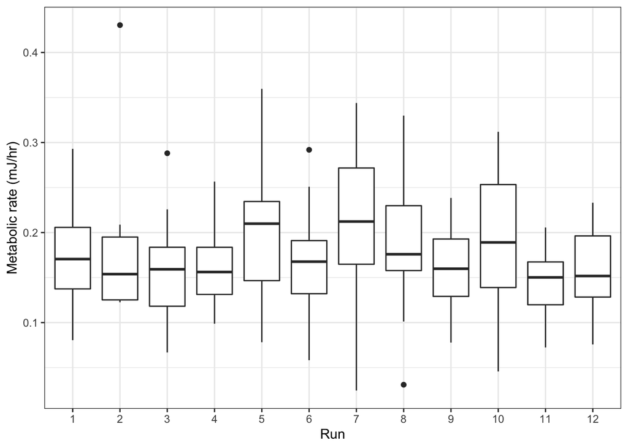

```r
bugula_early %>%
  ggplot(aes(x = as.factor(Run), y = Metabolic)) +
  geom_boxplot() +
  labs(x = "Run", y = "Metabolic rate (mJ/hr)") +
  theme_bw()
```

There does seem to be a little variation between runs.

**Grading:** 1 pt for plot, 1 pt for interpretation

### Question 3 (2 pts)

There are several reasons why random effects are useful here:

- We’re not interested in doing inference on the runs (that is, we don’t care about comparing run 1 to run 2)
- There are 12 different runs, which would add 11 parameters to the model if we used fixed effects instead. We can get a simpler model, which allows us to interpret the variability between runs, by using a random effect for run
- We can imagine differences between runs are due to random variation in the experimental conditions, so a random effect makes intuitive sense. And with 12 runs, we probably have enough to estimate the random effect

**Grading:** Any of these explanations is acceptable

### Question 4 (3 pts)

```r
m1 <- lmer(Metabolic ~ (1|Run), data = bugula_early)
summary(m1)
```

```
## Linear mixed model fit by REML ['lmerMod']
## Formula: Metabolic ~ (1 | Run)
##    Data: bugula_early
##
## REML criterion at convergence: -507.5
##
## Scaled residuals:
##     Min      1Q  Median      3Q     Max
## -2.5354 -0.6172 -0.0726  0.4840  3.9455
##
## Random effects:
##  Groups   Name        Variance Std.Dev.
##  Run      (Intercept) 0.000131 0.01145
##  Residual             0.004181 0.06466
## Number of obs: 197, groups:  Run, 12
##
## Fixed effects:
##             Estimate Std. Error t value
## (Intercept) 0.174662   0.005692   30.68
```

$\widehat{\beta}_0 = 0.175$, $\widehat{\sigma}_u^2 = 0.00013$, $\widehat{\sigma}_\varepsilon^2 = 0.0042$

**Grading:** If they used the wrong subset in question 1, they will get different results

### Question 5 (2 pts)

The average metabolic rate, across runs, is 0.175 mJ/hr

### Question 6 (3 pts)

$\widehat{\rho}_{group} = \dfrac{0.00013}{0.00013 + 0.0042} = 0.03$

So, about 3% of variability in metabolic rate is explained by random variation between runs. This is very low, and smaller intra class correlations suggest a random effect is not as important.

**Grading:** 1 pt for correlation, 1 pt for interpretation, 1 pt for whether large or small correlation means random effect is important

### Question 7 (3 pts)

$$Metabolic_{ij} = \beta_0 + \beta_1 Mass_{ij} + u_i + \varepsilon_{ij}$$

$u_i \overset{iid}{\sim} N(0, \sigma_u^2) \hspace{1cm} \varepsilon_{ij} \overset{iid}{\sim} N(0, \sigma_\varepsilon^2)$

**Grading:**

- Lose 1 pt for incorrect notation (e.g., missing subscripts)
- Lose 1 pt if they don’t include the distribution of random effects and noise

### Question 8 (3 pts)

```r
m1 <- lmer(Metabolic ~ Mass + (1|Run), data = bugula_early)
summary(m1)
```

```
## Linear mixed model fit by REML ['lmerMod']
## Formula: Metabolic ~ Mass + (1 | Run)
##    Data: bugula_early
##
## REML criterion at convergence: -522.6
##
## Scaled residuals:
##     Min      1Q  Median      3Q     Max
## -2.5472 -0.6527 -0.0767  0.5521  4.0772
##
## Random effects:
##  Groups   Name        Variance  Std.Dev.
##  Run      (Intercept) 0.0002778 0.01667
##  Residual             0.0035893 0.05991
## Number of obs: 197, groups:  Run, 12
##
## Fixed effects:
##             Estimate Std. Error t value
## (Intercept) 0.070604   0.020309   3.476
## Mass        0.007263   0.001347   5.391
##
## Correlation of Fixed Effects:
##      (Intr)
## Mass -0.948
```

$\widehat{\beta}_0 = 0.071$, $\widehat{\beta}_1 = 0.0073$, $\widehat{\sigma}_u^2 = 0.00028$, $\widehat{\sigma}_\varepsilon^2 = 0.0036$

### Question 9 (3 pts)

The average metabolic rate when mass is 0 (i.e. the average intercept), across runs, is 0.071 mJ/hr. For any given run, an increase of 1 $\mu$g in mass is associated with an increase of 0.0073 mJ/hr in metabolic rate.

### Question 10 (3 pts)

```r
coef(m1)$Run[3,]
```

```
##   (Intercept)        Mass
## 3  0.05315377 0.007263469
```

For Run 3, the estimated line is $0.053 + 0.0073 Mass_{ij}$. So, the predicted metabolic rate for a mass of 15 $\mu$g is $0.053 + 0.0073(15) = 0.163$ mJ/hr

### Question 11 (3 pts)

For a new run, the estimated line is $0.071 + 0.0073 Mass_{ij}$. So, the predicted metabolic rate for a mass of 15 $\mu$g is $0.071 + 0.0073(15) = 0.181$ mJ/hr.

### Question 12 (5 pts)

$\log L(\widehat{\lambda}) = \sum \limits_{i=1}^n \left( Y_i \log(\widehat{\lambda}) - \widehat{\lambda} - \log(Y_i!) \right)$

Differentiating, we get

$\dfrac{d}{d \widehat{\lambda}} \log L(\widehat{\lambda}) = \sum \limits_{i=1}^n \left( \dfrac{Y_i}{\widehat{\lambda}} - 1 \right)$

Setting to 0 and solving for $\widehat{\lambda}$, we get

$\widehat{\lambda} = \frac{1}{n} \sum \limits_{i=1}^n Y_i$